# Econometria Aplicada à Finanças Aula 9

Mestrado Profissional em Administração

Prof. Washington Santos da Silva

IFMG - Campus Formiga

14 de outubro de 2025

## Diário de Bordo

**O que vimos até o momento?**

- Aula 1 ✅
  - Apresentação da Disciplina ✅
  - Introdução ao RStudio ✅
  - Configurando o Projeto da Disciplina ✅
  - Conheça e Utilize o Terminal Git Bash ✅
- Aula 2 ✅
  - Git e GitHub: Visão Geral ✅
  - Introdução ao Sistema: Visão Geral ✅
  - Linguagem R: Visão Geral ✅
  - Sessão Prática 1 ✅
- Aula 3 ✅
  - Minicurso Intensivo: Teoria da Probabilidade - Parte 1 ✅
    - Introdução à Teoria da Probabilidade ✅
    - Variáveis Aleatórias e Distribuições de Probabilidade ✅
    - Distribuições Conjunta, Marginal e Condicional ✅
    - Independência de Variáveis Aleatórias ✅
- Aula 4 ✅
  - Minicurso Intensivo: Teoria da Probabilidade - Parte 2 ✅
    - Conceitos Básicos: Revisão ✅
    - Momentos de Distribuições de Probabilidade Univariadas ✅
    - Funções de Variáveis Aleatórias ✅
    - Fundamentos de Distribuições de Probabilidade Multivariadas ✅
    - Cálculo Diferencial e Integral em R
- Aula 5 ✅
  - Minicurso Intensivo: Teoria da Probabilidade - Parte 3 ✅
  - Distribuições de Variáveis Aleatórias Discretas ✅
  - Distribuições de Variáveis Aleatórias Contínuas ✅
  - Distribuições de Vetores Aleatórios ✅
  - A Ponte entre Probabilidade e Estatística/Econometria ✅
- Aula 6 ✅
  - Minicurso Intensivo: Métodos de Inferência Estatística I ✅
  - Estimação de Parâmetros: O Básico ✅
  - Métodos de Estimação de Parâmetros ✅
  - Estimação pode Intervalos de Confiança ✅
- Aula 7 ✅
  - Minicurso Intensivo: Métodos de Inferência Estatística II ✅
  - Propriedades dos Estimadores de Máxima Verossimilhança
  - Testes de Hipóteses (ou de Significância)
- Aula 8
  - Modelo de Regressão Linear: Fundamento
  - Modelo de Regressão Linear Simples

## Nesta Aula

**Tópicos**

- Modelo de Regressão Linear Múltipla: Diversos aspectos

**Diretrizes para Aulas Mais Produtivas**

⌨️ **Código com método:**

95% dos erros são evitáveis com:

- Respeitar a sequência lógica de etapas
- Revisão antes de pedir ajuda
- Atenção na digitação

🤝 **Inteligência colaborativa:**

- Compartilhe conhecimento
- Resolva questões técnicas simples com colegas próximos
- Reserve ao professor as dúvidas conceituais complexas

💪 **Capacidade de Resolver Problemas**

Cada problema/erro resolvido é uma evolução da sua habilidade analítica

# Modelo de Regressão Linear Múltipla

## Modelo de Regressão Linear Múltipla

**Mais variáveis explicativas**

Estamos mudando da **regressão linear simples**: uma variável resposta  
e uma variável explicativa :

$$\color{#e64173}{y_t} = \beta_0 + \beta_1 \color{#6A5ACD}{x_t} + u_t \,\, (t = 1, 2, \ldots, T)$$

para a **regressão linear múltipla**: uma variável resposta  
e diversas variáveis explicativas :

$$\color{#FF0000}{y_i} = \beta_1 + \beta_2 \color{#800080}{x_{2i}} + \beta_3 \color{#800080}{x_{3t}} + \cdots + \beta_k \color{#800080}{x_{kt}} + u_t
\,\, (t = 1, 2, \ldots, T)$$

**Por quê?**

Podemos, potencialmente:

- explicar melhor a variação em $y$;
- melhorar as previsões de $y_i$;
- evitar o **viés de variável omitida**;
- …

## Modelo de Regressão Linear Múltipla

**Forma Matricial**

$$\underset{(T \times 1)}{\mathbf{y}} =
\underset{(T \times k)}{\mathbf{X}}
\underset{(k \times 1)}{\boldsymbol{\beta}} +
\underset{(T \times 1)}{\boldsymbol{\epsilon}}$$

$$\begin{pmatrix}
y_1 \\
y_2 \\
\vdots \\
y_T
\end{pmatrix}
=
\begin{pmatrix}
1 & x_{21} & \dots & x_{k1} \\
1 & x_{22} & \dots & x_{k2} \\
\vdots & \vdots & \vdots & \vdots \\
1 & x_{2n} & \dots & x_{kT}
\end{pmatrix}
\begin{pmatrix}
\beta_1 \\
\beta_2 \\
\vdots \\
\beta_{k}
\end{pmatrix}
+
\begin{pmatrix}
\epsilon_1 \\
\epsilon_2 \\
\vdots \\
\epsilon_T
\end{pmatrix}$$

## Modelo de Regressão Linear Múltipla

**Hipóteses - sem álgebra matricial**

Para dados em **seção-cruzada**:

| Hipótese | Interpretação |
| --- | --- |
| H1. $y_i = \beta_1 + \beta_2 x_i + \varepsilon_i,\quad i = 1, \dots, T$ | $(y_i, x_i)$ satisfazem o modelo linear |
| H2. $\{(x_{i1},x_{i2},\ldots,x_{ik}, y_i) \}$ | amostra aleatória |
| H3. $E(\varepsilon_i\|X_i) = 0$ | erros tem média 0 condicional a $X$ |
| H4. $V(\varepsilon_i\|X_i) = \sigma^2 < \infty$ | variância finita e constante |
| H5. $Cov(\varepsilon_i,\varepsilon_i\|X_i) = 0$ | erros não são linearmente correlacionados |
| H6. $\varepsilon_i\|X_i \sim N(0,\sigma^2)$ | erros tem distribuição aprox. normal. |

**Ausência de colinearidade perfeita**

Para que as estimativas dos parâmetros $\beta_1, \dots, \beta_k$ sejam bem definidas, assume-se que **não há colinearidade perfeita** entre as variáveis explicativas, ou seja, nenhuma variável explicativa pode ser escrita como combinação linear exata das demais.

## Modelo de Regressão Linear Múltipla

**Hipóteses - com álgebra matricial**

Para dados em **seção-cruzada** com $T$ observações e $k$ regressores:

| Hipótese | Expressão | Interpretação |
| --- | --- | --- |
| **H1.** | $\mathbf{y} = \mathbf{X}\boldsymbol{\beta} + \boldsymbol{\epsilon}$ | O modelo é linear em parâmetros |
| **H2.** | $\{(\mathbf{x}_i^\top, y_i)\}_{i=1}^T$ | A amostra é aleatória (i.i.d.) |
| **H3.** | $E[\boldsymbol{\epsilon} \mid \mathbf{X}] = \mathbf{0}$ | Erros têm média condicional zero |
| **H4.** | $Var(\boldsymbol{\epsilon} \mid \mathbf{X}) = \sigma^2 \mathbf{I}_T$ | Erros são homocedásticos e não correlacionados |
| **H5.** | $\boldsymbol{\epsilon} \mid \mathbf{X} \sim \mathcal{N}(\mathbf{0}, \sigma^2 \mathbf{I}_T)$ | Erros têm distribuição normal multivariada (opcional) |

Sendo:

- ${\mathbf{I}_T}$: matriz identidade de ordem $T \times T$, supondo variância constante e ausência de correlação entre os erros.

## Modelo de Regressão Linear Múltipla

**Ausência de colinearidade perfeita**

Adicionalmente, assume-se que a matriz $\mathbf{X}$ tem **posto completo**, isto é:

$$\text{posto}(\mathbf{X}) = k
\quad \Leftrightarrow \quad \mathbf{X}^\top \mathbf{X} \text{ é inversível}$$

Essa condição garante que não há **colinearidade perfeita** entre os regressores, o que é necessário para que o estimador de MQO seja bem definido.

## Função de Expectativa Condicional

**Função de Regressão Linear e FEC**

Como sabemos , um modelo de regressão linear múltipla pode ser vista como uma estimativa da função de expectavia condicional (FEC) da variável dependente dado um conjunto de variáveis explicativas.

$$\begin{align*}
\mathbb{E}[y \mid \mathbf{X}] &= \mathbb{E}[\mathbf{X}\boldsymbol{\beta} + \epsilon \mid \mathbf{X}] \\
\mathbb{E}[y \mid \mathbf{X}] &= \mathbb{E}[\mathbf{X}\boldsymbol{\beta} \mid \mathbf{X}] + \mathbb{E}[\epsilon \mid \mathbf{X}]
\end{align*}$$

Como $\mathbf{X}\boldsymbol{\beta}$ é uma constante condicional a $\mathbf{X}$, segue que:

$$\mathbb{E}[\mathbf{X}\boldsymbol{\beta} \mid \mathbf{X}] = \mathbf{X}\boldsymbol{\beta}$$

Além disso, pela suposição de que $\mathbb{E}[\epsilon \mid \mathbf{X}] = 0$, temos:

$$\mathbb{E}[y \mid \mathbf{X}] = \mathbf{X}\boldsymbol{\beta} + 0$$

Portanto:

$$\mathbb{E}[y \mid \mathbf{X}] = \mathbf{X}\boldsymbol{\hat{\beta}} = \hat{y}$$

## Estimadores de MQO

**Esboço da Derivação - Modelo de Regressão Linear Múltipla**

Modelo de regressão múltipla na forma matricial:

$$\mathbf{y} = \mathbf{X}\boldsymbol{\beta} + \boldsymbol{\epsilon}$$

sendo:

- $\mathbf{y}$ um vetor de dimensão $T \times 1$;
- $\mathbf{X}$ a matriz de variáveis explicativas de dimensão $T \times k$ (com uma coluna de 1’s para o intercepto);
- $\boldsymbol{\beta}$ o vetor de parâmetros a serem estimados de dimensão $k \times 1$;
- $\boldsymbol{\epsilon}$ é o vetor de erros aleatórios de dimensão $T \times 1$.

Desejamos minimizar a soma dos quadrados dos resíduos, definida por:

$$S(\boldsymbol{\beta}) = \boldsymbol{\epsilon}'\boldsymbol{\epsilon}$$

Substituindo $\boldsymbol{\epsilon} = \mathbf{y} - \mathbf{X}\boldsymbol{\beta}$:

$$\boldsymbol{\epsilon}'\boldsymbol{\epsilon} = (\mathbf{y} - \mathbf{X}\boldsymbol{\beta})'(\mathbf{y} - \mathbf{X}\boldsymbol{\beta})$$

Expandindo o produto:

$$\boldsymbol{\epsilon}'\boldsymbol{\epsilon} = \mathbf{y}'\mathbf{y} - \mathbf{y}'\mathbf{X}\boldsymbol{\beta} - \boldsymbol{\beta}'\mathbf{X}'\mathbf{y} + \boldsymbol{\beta}'\mathbf{X}'\mathbf{X}\boldsymbol{\beta}$$

Utilizando que $\mathbf{y}'\mathbf{X}\boldsymbol{\beta}$ é escalar, podemos reescrever:

$$\boldsymbol{\epsilon}'\boldsymbol{\epsilon} = \mathbf{y}'\mathbf{y} - 2\mathbf{y}'\mathbf{X}\boldsymbol{\beta} + \boldsymbol{\beta}'\mathbf{X}'\mathbf{X}\boldsymbol{\beta}$$

Para encontrar o vetor de estimadores $\hat{\boldsymbol{\beta}}$, tomamos a derivada de $S(\boldsymbol{\beta})$ em relação a $\boldsymbol{\beta}$, termo a termo:

$$\frac{\partial}{\partial \boldsymbol{\beta}} \left( \mathbf{y}'\mathbf{y} - 2\mathbf{y}'\mathbf{X}\boldsymbol{\beta} + \boldsymbol{\beta}'\mathbf{X}'\mathbf{X}\boldsymbol{\beta} \right)
= -2\mathbf{X}'\mathbf{y} + 2\mathbf{X}'\mathbf{X}\boldsymbol{\beta}$$

Igualando a zero (condição de primeira ordem):

$$-2\mathbf{X}'\mathbf{y} + 2\mathbf{X}'\mathbf{X}\boldsymbol{\beta} = 0$$

Reorganizando os termos:

$$\mathbf{X}'\mathbf{X}\boldsymbol{\beta} = \mathbf{X}'\mathbf{y}$$

Assumindo que $\mathbf{X}'\mathbf{X}$ é não singular (invertível), podemos resolver para $\boldsymbol{\beta}$:

$$\hat{\boldsymbol{\beta}} = (\mathbf{X}'\mathbf{X})^{-1}\mathbf{X}'\mathbf{y}$$

Assim, a expressão matricial dos estimadores de MQO dos parâmetros do modelo de regressão múltipla é:

$$\boxed{\hat{\boldsymbol{\beta}} = (\mathbf{X}'\mathbf{X})^{-1}\mathbf{X}'\mathbf{y}}$$

## Melhor Plano de Ajuste

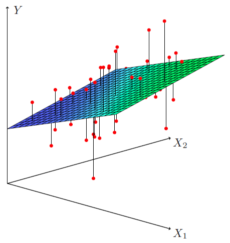

## Estimador da Variância dos Resíduos

**Esboço da Derivação**

Após estimar os coeficientes $\hat{\boldsymbol{\beta}}$ usando MQO, o vetor de resíduos $\hat{\boldsymbol{\epsilon}}$ é dado por:

$$\hat{\boldsymbol{\epsilon}} = \mathbf{y} - \mathbf{X}\hat{\boldsymbol{\beta}} = \mathbf{y} - \hat{\mathbf{y}}$$

A variância do erro $\sigma^2$ é estimada pela soma dos quadrados dos resíduos dividida pelos graus de liberdade:

$$\boxed{\hat{\sigma}^2 = \frac{\hat{\boldsymbol{\epsilon}}'\hat{\boldsymbol{\epsilon}}}{T - k}}$$

Substituindo a expressão para os resíduos:

$$\boxed{\hat{\sigma}^2 = \frac{\left(\mathbf{y} - \mathbf{X}\hat{\boldsymbol{\beta}}\right)'\left(\mathbf{y} - \mathbf{X}\hat{\boldsymbol{\beta}}\right)}{T - k}}$$

Assim, o estimador da variância dos resíduos pode ser escrito como:

$$\hat{\sigma}^2 = \frac{\hat{\boldsymbol{\epsilon}}'\hat{\boldsymbol{\epsilon}}}{T - k} = \frac{SQR}{T - k}$$

## $T - k$ ou $T - k - 1$?

**Diferença na Definição de (k)**

A fórmula geral do estimador da variância dos resíduos é:

$$\hat{\sigma}^2 = \frac{SQR}{\text{graus de liberdade residuais}} = \frac{\hat{\boldsymbol{\epsilon}}'\hat{\boldsymbol{\epsilon}}}{T - \text{nº de parâmetros estimados}}$$

A diferença entre as expressões $T - k$ e $T - k - 1$ está na forma como o número de parâmetros estimados é contado:

#### Brooks (2019)

- Define $k$ como o número total de parâmetros estimados, **incluindo** o intercepto.
- Assim, usa diretamente:

  $$\hat{\sigma}^2 = \frac{SQR}{T - k}$$

#### Wooldridge (2006)

- Define $k$ como o número de variáveis explicativas, **excluindo** o intercepto.
- Então o número total de parâmetros estimados é $k + 1$, e:

  $$\hat{\sigma}^2 = \frac{SQR}{T - k - 1}$$

Ambas as abordagens são corretas, desde que fique claro o que está incluído em k.

## Estimador da Matriz de Variâncias-Covariâncias

**Esboço da Derivação**

Consideremos novamente o modelo de regressão linear múltipla:

$$\mathbf{y} = \mathbf{X}\boldsymbol{\beta} + \boldsymbol{\epsilon}$$

Sob as hipóteses clássicas de Gauss–Markov (condicionais em $\mathbf{X}$):

$$\mathbb{E}[\boldsymbol{\epsilon}\mid \mathbf{X}] = \mathbf{0},
\qquad
\mathrm{Var}(\boldsymbol{\epsilon}\mid \mathbf{X}) = \sigma^2 \mathbf{I},
\qquad
\mathrm{rank}(\mathbf{X}) = k.$$

O estimador de MQO dos parâmetros é dado por:

$$\hat{\boldsymbol{\beta}} = (\mathbf{X}'\mathbf{X})^{-1}\mathbf{X}'\mathbf{y}.$$

#### Derivação da Variância de $\hat{\boldsymbol{\beta}}$

Substituímos o modelo na expressão do estimador:

$$\hat{\boldsymbol{\beta}}
= (\mathbf{X}'\mathbf{X})^{-1} \mathbf{X}' (\mathbf{X}\boldsymbol{\beta} + \boldsymbol{\epsilon})
= \boldsymbol{\beta} + (\mathbf{X}'\mathbf{X})^{-1} \mathbf{X}' \boldsymbol{\epsilon}$$

Como $\boldsymbol{\beta}$ é constante, temos:

$$\mathrm{Var}(\hat{\boldsymbol{\beta}} \mid \mathbf{X}) = \mathrm{Var} \left( (\mathbf{X}'\mathbf{X})^{-1} \mathbf{X}' \boldsymbol{\epsilon} \,\middle|\, \mathbf{X} \right)$$

Usando a propriedade de variância de transformação linear:

$$\mathrm{Var}(A\mathbf{z}) = A\,\mathrm{Var}(\mathbf{z})\,A' \quad \Rightarrow \quad
\mathrm{Var}(\hat{\boldsymbol{\beta}} \mid \mathbf{X}) = (\mathbf{X}'\mathbf{X})^{-1} \mathbf{X}'\,\mathrm{Var}(\boldsymbol{\epsilon}\mid \mathbf{X})\,\mathbf{X} (\mathbf{X}'\mathbf{X})^{-1}$$

Substituindo $\mathrm{Var}(\boldsymbol{\epsilon} \mid \mathbf{X}) = \sigma^2 \mathbf{I}$:

$$\boxed{
\mathrm{Var}(\hat{\boldsymbol{\beta}} \mid \mathbf{X}) = \sigma^2 (\mathbf{X}'\mathbf{X})^{-1}
}$$

#### Estimador da Variância-Covariância

Como $\sigma^2$ é desconhecido, substituímos pelo estimador não viesado:

$$\hat{\sigma}^2 = \frac{\hat{\boldsymbol{\epsilon}}' \hat{\boldsymbol{\epsilon}}}{T - k}$$

Assim, o estimador da matriz de variâncias-covariâncias dos coeficientes é:

$$\boxed{
\widehat{\mathrm{Var}}(\hat{\boldsymbol{\beta}}) = \hat{\sigma}^2 (\mathbf{X}'\mathbf{X})^{-1}
}$$

#### Representação Matricial (Exemplo Simbólico)

Para fins ilustrativos, suponha que o vetor $\hat{\boldsymbol{\beta}}$ tenha três elementos.  
A matriz de variâncias-covariâncias estimadas pode ser representada simbolicamente como:

$$\widehat{\mathrm{Var}}(\hat{\boldsymbol{\beta}}) =
\begin{bmatrix}
\hat{\sigma}_{00} & \hat{\sigma}_{01} & \hat{\sigma}_{02} \\
\hat{\sigma}_{10} & \hat{\sigma}_{11} & \hat{\sigma}_{12} \\
\hat{\sigma}_{20} & \hat{\sigma}_{21} & \hat{\sigma}_{22}
\end{bmatrix}
\quad \text{com} \quad
\hat{\sigma}_{ij} = \hat{\sigma}^2 \, [(\mathbf{X}'\mathbf{X})^{-1}]_{ij}$$

- Note que a matriz $\widehat{\mathrm{Var}}(\hat{\boldsymbol{\beta}})$ é simétrica, pois $(\mathbf{X}'\mathbf{X})^{-1}$ também é simétrica.
- Os elementos **diagonais** correspondem às **variâncias estimadas** de cada $\hat{\beta}_j$:
  $$\mathrm{Var}(\hat{\beta}_j) = \hat{\sigma}_{jj} = \hat{\sigma}^2 \, [(\mathbf{X}'\mathbf{X})^{-1}]_{jj}$$
- Os elementos **fora da diagonal** representam as **covariâncias estimadas** entre os coeficientes:
  $$\mathrm{Cov}(\hat{\beta}_i, \hat{\beta}_j) = \hat{\sigma}_{ij}$$

Os **erros-padrão individuais** são as raízes das variâncias na diagonal:

$$\boxed{
EP(\hat{\beta}_j) = \sqrt{\hat{\sigma}_{jj}} = \sqrt{\left[\widehat{\mathrm{Var}}(\hat{\boldsymbol{\beta}})\right]_{jj}} \quad \text{para } j = 0, 1, 2
}$$

## Exemplo - Wooldridge (2006)

**Estimadores de MQO dos Parâmetros ($\hat{\beta}$)**

$$\hat{\beta} = (X'X)^{-1}X'y$$

```r
# carrega os dados
data(gpa1, package='wooldridge')

# determina n = tamanho da amostra
n <- nrow(gpa1)

# define o número de parâmetros (k)
# beta_1 (intercepto), beta_2 e beta_3
k <- 3

# extrai y
y <- gpa1$colGPA

# extrai X e adiciona uma coluna de 1's para o intercepto
X <- cbind(1, gpa1$hsGPA, gpa1$ACT)

# exibe as primeiras linhas de X
head(X)
```

```
#>      [,1] [,2] [,3]
#> [1,]    1  3.0   21
#> [2,]    1  3.2   24
#> [3,]    1  3.6   26
#> [4,]    1  3.5   27
#> [5,]    1  3.9   28
#> [6,]    1  3.4   25
```

```r
# calcula as estimativas de MQO dos parâmetros
# (X'X)^(-1) * X' * y
betahat <- solve(t(X) %*% X) %*% t(X) %*% y
betahat
```

```
#>          [,1]
#> [1,] 1.286328
#> [2,] 0.453456
#> [3,] 0.009426
```

## Exemplo - Wooldridge (2006)

**Estimativa da Variância dos Resíduos ($\hat{\sigma^2}$)**

$$\hat{\sigma}^2 = \frac{\hat{\epsilon}'\hat{\epsilon}}{n - k} = \frac{SQR}{n - k}$$

```r
# obtém os resíduos do modelo
residuos <- y - X %*% betahat

# obtém a variância dos resíduos
sigma_hat <- as.numeric(t(residuos) %*% residuos / (n-k))
sigma_hat
```

```
#> [1] 0.11581
```

```r
# obtém o erro padrão dos resíduos
# também chamado de erro-padrão da regressão
erro_padrao_residuos <- sqrt(sigma_hat)
erro_padrao_residuos
```

```
#> [1] 0.34032
```

## Exemplo - Wooldridge (2006)

**Estimativa da Matriz de Variâncias-Covariâncias de $\hat{\beta}$**

$$\hat{\text{Var}}(\hat{\beta}) = \hat{\sigma}^2 (X'X)^{-1}$$

```r
# variâncias estimadas das estimativas dos parâmetros
vcov_hat <- sigma_hat * solve( t(X) %*% X)
vcov_hat
```

```
#>            [,1]        [,2]        [,3]
#> [1,]  0.1161597 -0.02260637 -0.00159085
#> [2,] -0.0226064  0.00918011 -0.00035708
#> [3,] -0.0015908 -0.00035708  0.00011615
```

```r
# erros-padrão das estimativas dos parâmetros
erros_padrao_betahat <- sqrt(diag(vcov_hat))
erros_padrao_betahat
```

```
#> [1] 0.340822 0.095813 0.010777
```

## Exemplo - Wooldridge (2006) - Verificação

```r
# usando a função lm
reg_gpa <- lm(colGPA ~ hsGPA + ACT, data = gpa1)

# estimativa dos parâmetros e do erro-padrão da regressão
summary(reg_gpa)
```

```
#>
#> Call:
#> lm(formula = colGPA ~ hsGPA + ACT, data = gpa1)
#>
#> Residuals:
#>     Min      1Q  Median      3Q     Max
#> -0.8544 -0.2467 -0.0261  0.2813  0.8536
#>
#> Coefficients:
#>             Estimate Std. Error t value  Pr(>|t|)
#> (Intercept)  1.28633    0.34082    3.77   0.00024 ***
#> hsGPA        0.45346    0.09581    4.73 0.0000054 ***
#> ACT          0.00943    0.01078    0.87   0.38330
#> ---
#> Signif. codes:  0 '***' 0.001 '**' 0.01 '*' 0.05 '.' 0.1 ' ' 1
#>
#> Residual standard error: 0.34 on 138 degrees of freedom
#> Multiple R-squared:  0.176,  Adjusted R-squared:  0.164
#> F-statistic: 14.8 on 2 and 138 DF,  p-value: 0.00000153
```

```r
# estimativa da variância do resíduo
names(reg_gpa)
```

```
#>  [1] "coefficients"  "residuals"     "effects"       "rank"
#>  [5] "fitted.values" "assign"        "qr"            "df.residual"
#>  [9] "xlevels"       "call"          "terms"         "model"
```

```r
# estimativa da matriz de variância-covariância
vcov(reg_gpa)
```

```
#>             (Intercept)       hsGPA         ACT
#> (Intercept)   0.1161597 -0.02260637 -0.00159085
#> hsGPA        -0.0226064  0.00918011 -0.00035708
#> ACT          -0.0015908 -0.00035708  0.00011615
```

# Interpretação das estimativas dos parâmetros

## Variáveis Numéricas Contínuas

**Interpretação**

Considere o seguinte modelo de regressão linear simples:

$$\text{Salário}_i = \beta_0 + \beta_1 \, \text{Escola}_i + u_i$$

sendo:

- $\text{Salário}_i$ uma variável contínua que mede o salário de um indivíduo.
- $\text{Educacao}_i$ uma variável contínua que medida em anos de educação formal.

**Interpretações**

- $\beta_0$: o intercepto-$y$, *i.e.*, $\text{Salário}$ quando $\text{Escola} = 0$.
- $\beta_1$: o aumento esperado em $\text{Salário}$ para um aumento de uma unidade em $\text{Educacao}$

## Variáveis Numéricas Contínuas

**Interpretação**

Derivando a interpretação de $\beta_1$:

$$\begin{aligned}
\mathop{\boldsymbol{E}}\left[ \text{Salario} | \text{Educacao} = \ell + 1 \right] - \mathop{\boldsymbol{E}}\left[ \text{Salario} | \text{Educacao} = \ell \right] &= \\[0.5em]
\mathop{\boldsymbol{E}}\left[ \beta_0 + \beta_1 (\ell + 1) + u \right] - \mathop{\boldsymbol{E}}\left[ \beta_0 + \beta_1 \ell + u \right] &= \\[0.5em]
\left[ \beta_0 + \beta_1 (\ell + 1) \right] - \left[ \beta_0 + \beta_1 \ell \right] &= \\[0.5em]
\beta_0 - \beta_0 + \beta_1 \ell - \beta_1 \ell + \beta_1 &=
\beta_1
\end{aligned}$$

*I.e.*, $\beta_1$ fornece o aumento esperado na variável resposta para um aumento de uma unidade na variável explicativa.

## Variáveis Numéricas Contínuas

**Interpretação**

Se tivermos múltiplas variáveis explicativas, *por exemplo*:

$$\text{Salario}_i = \beta_0 + \beta_1 \, \text{Educacao}_i + \beta_2 \, \text{Habilidade}_i + u_i$$

então a interpretação muda um pouco:

$$\begin{aligned}
\mathop{\boldsymbol{E}}\left[ \text{Salario} | \text{Educacao} = \ell + 1 \land \text{Habilidade} = \alpha \right] - & \\
\mathop{\boldsymbol{E}}\left[ \text{Salario} | \text{Educacao} = \ell \land \text{Habilidade} = \alpha \right] &= \\
\mathop{\boldsymbol{E}}\left[ \beta_0 + \beta_1 (\ell + 1) + \beta_2 \alpha + u \right] -
\mathop{\boldsymbol{E}}\left[ \beta_0 + \beta_1 \ell + \beta_2 \alpha + u \right] &= \\
\left[ \beta_0 + \beta_1 (\ell + 1) + \beta_2 \alpha \right] -
\left[ \beta_0 + \beta_1 \ell + \beta_2 \alpha \right] &= \\
\beta_0 - \beta_0 + \beta_1 \ell - \beta_1 \ell + \beta_1 + \beta_2 \alpha - \beta_2 \alpha &=
\beta_1
\end{aligned}$$

*I.e.*, $\beta_1$ fornece o aumento esperado na variável resposta para um aumento de uma unidade na variável explicativa, **mantendo todas as outras variáveis constantes** (*ceteris paribus*).

- **Derivação alternativa**

Considere o modelo

$$y = \beta_0 + \beta_1 \, x + u$$

Diferencie o modelo em relação a $x$:

$$\dfrac{dy}{dx} = \beta_1$$

## Variáveis Categóricas

**Interpretação**

Considere o modelo de regressão linear simples:

$$\text{Salário}_i = \beta_0 + \beta_1 \, \text{Mulher}_i + u_i$$

sendo:

- $\text{Salário}_i$ uma variável contínua que mede o salário de um indivíduo.
- $\text{Mulher}_i$ uma variável binária igual a $1$ quando $i$ é mulher.

**Interpretações:**

- $\beta_0$: o $\text{Salário}$ esperado para homens (*i.e.*, quando $\text{Mulher} = 0$).
- $\beta_1$: a diferença esperada do $\text{Salário}$ entre mulheres e homens.
- $\beta_0 + \beta_1$: o $\text{Salário}$ esperado para mulheres.

## Variáveis Categóricas

**Interpretação**

Derivação:

$$\begin{aligned}
\mathop{\boldsymbol{E}}\left[ \text{Salario} | \text{Homem} \right] &=
\mathop{\boldsymbol{E}}\left[ \beta_0 + \beta_1\times 0 + u_i \right] \\
&= \mathop{\boldsymbol{E}}\left[ \beta_0 + 0 + u_i \right] \\
&= \beta_0
\end{aligned}$$

$$\begin{aligned}
\mathop{\boldsymbol{E}}\left[ \text{Salario} | \text{Mulher} \right] &=
\mathop{\boldsymbol{E}}\left[ \beta_0 + \beta_1\times 1 + u_i \right] \\
&= \mathop{\boldsymbol{E}}\left[ \beta_0 + \beta_1 + u_i \right] \\
&= \beta_0 + \beta_1
\end{aligned}$$

**Obs.:**

- Se não houver outras variáveis para condicionar, então $\hat{\beta}_1$ é igual à diferença nas médias dos grupos, *por exemplo*, $\overline{x}_\text{Mulher} - \overline{x}_\text{Homem}$.
- A interpretação de *manter todas as outras variáveis constantes* também se aplica a variáveis categóricas em modelos de regressão múltipla.

## Interações

**Interpretação**

As interações permitem que o efeito de uma variável mude com base no nível de outra variável.

**Exemplos**

- O efeito da escolaridade no salário muda por gênero?
- O efeito do gênero no salário muda por raça?
- O efeito da escolaridade no salário muda por experiência?

## Interações

**Interpretação**

- Anteriormente, consideramos um modelo que permitia que mulheres e homens tivessem salários diferentes, mas o modelo assumia que o efeito da educação no salário era o mesmo para todos:

$$\text{Salário}_i = \beta_0 + \beta_1 \, \text{Educacao}_i + \beta_2 \, \text{Mulher}_i + u_i$$

- mas podemos permitir também que o efeito da educação varie por gênero:

$$\text{Salário}_i = \beta_0 + \beta_1 \, \text{Educacao}_i + \beta_2 \, \text{Mulher}_i + \beta_3 \, \text{Educacao}_i\times\text{Mulher}_i + u_i$$

## Interações

- modelo onde a educacao tem o mesmo efeito para todos (Mulher e Homem):

[figure not shown]

## Interações

- modelo em que o efeito da educação pode diferir por gênero (Mulher e Homem):

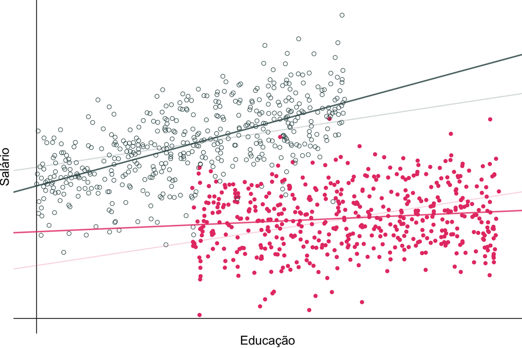

## Interações

**Interpretação**

Interpretar coeficientes pode ser um pouco complicado com interações, mas o segredo é trabalhar cuidadosamente a matemática:

$$\text{Salário}_i = \beta_0 + \beta_1 \, \text{Educação}_i + \beta_2 \, \text{Mulher}_i + \beta_3 \, \text{Educação}_i\times\text{Mulher}_i + u_i$$
Retornos esperados para um ano adicional de escolaridade para mulheres:

$$\begin{aligned}
\mathop{\boldsymbol{E}}\left[ \text{Salário}_i | \text{Mulher} \land \text{Educação} = \ell + 1 \right] -
\mathop{\boldsymbol{E}}\left[ \text{Salário}_i | \text{Mulher} \land \text{Educação} = \ell \right] &= \\
\mathop{\boldsymbol{E}}\left[ \beta_0 + \beta_1 (\ell+1) + \beta_2 + \beta_3 (\ell + 1) + u_i \right] -
\mathop{\boldsymbol{E}}\left[ \beta_0 + \beta_1 \ell + \beta_2 + \beta_3 \ell + u_i \right] &= \\
\beta_1 + \beta_3
\end{aligned}$$

- De forma similar, $\beta_1$ fornece o retorno esperado para um ano adicional de educação para homens.
- Assim, $\beta_3$ fornece a **diferença nos retornos da educação** para mulheres e homens.

# Ausência de Colinearidade Perfeita - $posto(X) = k$

## $posto(X) = k$

**Descrição**

- Na amostra (e, portanto, na população), **nenhuma das variáveis** **explicativas é constante** e;
- **Não há correlações lineares exatas** entre as variáveis explicativas.
- Pode haver correlações lineares altas (multicolinearidade), mas não exatas ou perfeitas

## Multicolinearidade

**Descrição**

Considere um modelo de regressão linear múltipla:

$$y = \beta_0 + \beta_1 X_1 + \beta_2 X_2 + \dots + \beta_k X_k + \epsilon$$

Multicolinearidade ocorre quando existe uma **dependência linear** **quase** exata entre duas ou mais variáveis explicativas ($x$).

Formalmente, isso significa que existe um vetor **não nulo** $\lambda = (\lambda_1, \lambda_2, \dots, \lambda_k)$$ tal que:

$$\lambda_1 X_1 + \lambda_2 X_2 + \dots + \lambda_k X_k \approx 0$$
Essa relação indica que uma variável explicativa pode ser expressa como uma combinação linear das outras:

$$x_j = \sum_{i \neq j} \lambda_k x_j$$
- Em outras palavras, cada variável explicativa na especificação não pode ser uma média ponderada das outras variáveis explicativas.

## Colinearidade Perfeita

```r
# modelo de regressão simulado (k = 3) com multicolinearidade exata
set.seed(42)
x1 <- runif(100)
x2 <- 2 * x1        # x2 = 2*(x1)
y <- rnorm(100)
df <- data.frame(y, x1, x2)

lm(y ~ x1 + x2, data = df)
```

```
#>
#> Call:
#> lm(formula = y ~ x1 + x2, data = df)
#>
#> Coefficients:
#> (Intercept)           x1           x2
#>      -0.254        0.436           NA
```

## Multicolinearidade

**Álgebra Linear Numérica**

- Sabemos que os estimadores de MQO são dados por

$$\hat{\boldsymbol{\beta}} = (\mathbf{X}^\top\mathbf{X})^{-1}\mathbf{X}'\mathbf{y}$$

Quando há multicolinearidade entre as colunas da matriz $X$, isso implica que as colunas são linearmente dependentes ou quase dependentes.

Em termos de álgebra linear numérica, isso resulta nas seguintes consequências:

**Determinante Próximo de Zero**:

- A matriz $\mathbf{X}'\mathbf{X}$ torna-se quase singular, significando que seu determinante é muito próximo de zero.

**Instabilidade Numérica na Inversão**:

- A consequência direta da quase singularidade é que a inversão da matriz $(\mathbf{X}^\top \mathbf{X})^{-1}$ torna-se numericamente instável. Pequenas variações nos dados podem resultar em grandes mudanças nos coeficientes estimados $\hat{\beta}$, pois a inversão de uma matriz quase singular amplifica os erros numéricos. Esse fenômeno é conhecido como problema de “condicionamento” da matriz.
- Embora a linguagem R utilize a **Decomposição QR** para obter os estimadores de MQO, e não o cálculo da inversa de $(\mathbf{X}^\top \mathbf{X})^{-1}$, o que oferece vantagens em termos da estabilidade numérica, a multicolinearidade continua a afetar negativamente a obtenção dos estimadores de MQO.

## Fator de Inflação da Variância

**VIF - *Variance Inflation Factor***

Para um modelo de regressão linear múltipla:

$$y_i = \beta_0 + \beta_1 X_{i1} + \beta_2 X_{i2} + \dots + \beta_k X_{ik} + \epsilon_i$$
A variância do estimador $\hat{\beta}_j$ pode ser obtida por:

$$\begin{aligned}
V(\hat{\beta}_j) &= \hat{\sigma}^2 \times \frac{1}{\sum_{i=1}^{n} (X_{ij} - \bar{X}_j)^2 \cdot (1 - R_j^2)} \\
&= \hat{\sigma}^2 \times \frac{1}{\sum_{i=1}^{n} (X_{ij} - \bar{X}_j)^2} \times
\frac{1}{(1 - R_j^2)}
\end{aligned}$$

onde: - $\hat{\sigma}^2$ é o estimador da variância do erro $\epsilon_i$:

$$\hat{\sigma}^2 = \frac{\sum_{i=1}^{n} \hat{\epsilon}_i^2}{n - k - 1}$$

- $\sum_{i=1}^{n} (X_{ij} - \bar{X}_j)^2$ é a soma dos quadrados dos desvios da variável $X_j$ em relação à sua média $\bar{X}_j$.
- $R_j^2$ é o coeficiente de determinação da regressão da variável $X_j$ em relação a todas as outras variáveis explicativas no modelo.
- O fator de inflação da variância (VIF) para o coeficiente (_j) é definido como:

$$\text{VIF}(X_j) = \frac{1}{1 - R_j^2}$$

onde $R_j^2$ é o coeficiente de determinação da regressão de $X_j$ em relação às outras variáveis explicativas.

Podemos reescrever a variância $V(\hat{\beta}_j)$ substituindo o $R_j^2$ na fórmula anterior:

$$\begin{aligned}
V(\hat{\beta}_j) &= \hat{\sigma}^2 \times \frac{1}{\sum_{i=1}^{n} (X_{ij} - \bar{X}_j)^2} \times
\frac{1}{(1 - R_j^2)}\\
&= \hat{\sigma}^2 \times \frac{\text{VIF}(X_j)}{\sum_{i=1}^{n} (X_{ij} - \bar{X}_j)^2}
\end{aligned}$$

Isso mostra que:

- Quanto maior a variância do erro $V(\sigma^2)$, maior $V(\hat{\beta})$. Mais “ruído” na equação torna mais difícil estimar o efeito parcial de qualquer uma das variáveis explicativas em $y$, e isso se reflete em maiores variâncias para os estimadores de MQO. $\sigma^2$ é uma característica da população, não tem nada a ver com o tamanho da amostra.
- Quanto maior a variação total em $x_j$, menor é $V(\hat{\beta})$. Assim, tudo o mais constante, para estimar $\beta_j$ preferimos ter o máximo de variação amostra em $x_j$ possível. Embora raramente seja possível escolhermos os valores das variáveis explicativas, há uma maneira de aumentar a variação da amostra em cada uma das variáveis explicativas: aumentar o tamanho da amostra. Este é o componente da variância que depende sistematicamente do tamanho da amostra.
- Na medida em que $R_j^2$ aumenta (fica mais próximo de 1), $V(\hat{\beta})$ aumenta cada vez mais. Assim, um alta grau de dependência linear entre as colunas de $X$ pode produzir altas $V(\hat{\beta})$.

## Fator de Inflação da Variância

**“Regra de Bolso” = Arbitrária**

- $VIF_j > 10$ - Multicolinearidade é um problema.
- $VIF_j < 10$ - Multicolinearidade nào é um problema.

**Limitações**:

- Se temos boas razões para considerar que certas variáveis explicativas precisam ser incluídas em uma regressão para inferir o impacto de de $x_j$, então hesitamos em removê-las, e um $VIF_j$ “muito alto” não pode realmente afetar essa decisão.
- Definir um valor de corte para o VIF acima do qual concluímos que a multicolinearidade é um “problema” é arbitrário e não especialmente útil.
- Às vezes, o valor 10 é escolhido: se o $VIF_j$ estiver acima de 10 (equivalente a $R^2_j$ acima de 0,9), então concluímos que a multicolinearidade é um “problema” para estimar $\beta_j$.
- Mas um (VIF_j) acima de 10 não significa que o desvio padrão de $\hat{$}_j$ seja grande demais para ser útil, porque o desvio padrão também depende de $\sigma$ e $SST_j$, e esta última pode ser aumentada. aumentando o tamanho da amostra.
- Portanto, assim como olhar diretamente para o tamanho de $R^2_j$, olhar para o tamanho de $VIF_j$ é de utilidade limitada, embora alguém possa querer fazer isso por curiosidade.

## Fator de Inflação da Variância em R

```r
# pacote necessário
library(car)

# estime um modelo de regressão linear múltipla usando
# dados internos do R
lm_mtcars <- lm(mpg ~ ., data = mtcars)

# VIF
car::vif(lm_mtcars)
```

```
#>     cyl    disp      hp    drat      wt    qsec      vs      am    gear    carb
#> 15.3738 21.6202  9.8320  3.3746 15.1649  7.5280  4.9659  4.6485  5.3575  7.9087
```

## Multicolinearidade

**Consequências**

A presença de multicolinearidade nas colunas da matriz $\mathbf{X}$ de um modelo de regressão linear múltipla tem as seguintes consequências:

1. **Instabilidade dos Parâmetros Estimados**: Os parâmetros estimados ($\hat{\beta}$) se tornam muito sensíveis a pequenas alterações nos dados, levando a estimativas instáveis e menos confiáveis.
2. **Alta Variância dos Estimadores**: A variância (erro padrão) dos parâmetros estimados ($\hat{\beta}$) aumenta, reduzindo a precisão das estimativas e dificultando a identificação de quais variáveis são realmente significativas.
3. **Dificuldade na Interpretação**: Devido à alta correlação entre as variáveis explicativas, torna-se difícil separar os efeitos individuais de cada variável explicativa, complicando a interpretação dos coeficientes.
4. **Problemas de Identificação**: Em casos extremos, a multicolinearidade pode resultar em uma matriz $(X^\top X)$ quase singular ou singular, o que dificulta ou impossibilita calcular os coeficientes de regressão

## Multicolinearidade

**Abordagens para Lidar com Multicolinearidade**

| Técnica | O que melhora com a multicolinearidade | Objetivo principal | Permite inferência? | Tipo |
| --- | --- | --- | --- | --- |
| Fator de Inflação da Variância (VIF) + seleção manual | Ajuda a identificar e remover variáveis redundantes | Diagnóstico e simplificação do modelo | Sim (após ajuste) | Clássica |
| Regressão Ridge | Reduz a variância dos coeficientes | Estabilidade na previsão | Parcial | Clássica |
| Regressão por Componentes Principais (PCR) | Substitui variáveis correlacionadas por componentes ortogonais | Redução de dimensionalidade para previsão | Não | Clássica |
| Regressão por Mínimos Quadrados Parciais (PLS) | Constrói componentes que explicam as variáveis e a resposta | Estabilidade na previsão com alguma interpretabilidade | Com reamostragem | Moderna |
| Regressão Bayesiana | Usa distribuições a priori para controlar a instabilidade | Inferência com regularização | Sim | Moderna |
| Regressão LASSO | Reduz o número de variáveis no modelo | Previsão e seleção de variáveis | Não | Moderna |
| Regressão Elastic Net | Combina estabilidade e seleção | Previsão com variáveis correlacionadas | Não | Moderna |

# H3 $E(\epsilon_i|X_i) = 0$ - Exogeneidade

## H3: $\mathbb{E}(\varepsilon_i \mid X_i) = 0$

**Hipótese de Exogeneidade**

A hipótese de **exogeneidade** do modelo de regressão linear clássico exige:

$$\boxed{\mathbb{E}(\varepsilon_i \mid X_i) = 0}$$

onde $X_i$ representa o vetor de variáveis explicativas da i-ésima observação.

#### Implicações formais:

- Pela **lei das expectativas iteradas**:

$$\mathbb{E}(\varepsilon_i \mid X_i) = 0 \quad \Rightarrow \quad \mathbb{E}(\varepsilon_i) = 0$$

- e

$$\mathbb{E}(\varepsilon_i \mid X_i) = 0 \quad \Rightarrow \quad \mathrm{Cov}(x_{ij}, \varepsilon_i) = 0$$

#### Comparação com hipóteses mais fracas:

A hipótese $\mathbb{E}(\varepsilon_i \mid X_i) = 0$ é **mais forte** que:

- $\mathbb{E}(\varepsilon_i) = 0$: média incondicional nula;
- $\mathrm{Cov}(x_{ij}, \varepsilon_i) = 0$: não correlação entre o erro e qualquer variável explicativa.

Essas **não garantem** exogeneidade condicional.

#### Importância

Essa hipótese garante que:

- Os erros não estão sistematicamente relacionados a $X_i$;
- Os estimadores de MQO são **não viesados** e **consistentes**.

## Violação de $\mathbb{E}(\varepsilon_i \mid X_i) = 0$

**Endogeneidade = Violação da Exogeneidade**

A exogeneidade falha quando:

$$\mathbb{E}(\varepsilon_i \mid X_i) \neq 0$$

ou seja, o erro está **sistematicamente correlacionado com variáveis explicativas**.

#### Diagnóstico parcial (mas insuficiente)

Mesmo que:

- $\mathbb{E}(\varepsilon_i) = 0$, e
- $\mathrm{Cov}(x_{ij}, \varepsilon_i) = 0$

**ainda assim pode haver endogeneidade**, pois essas condições **não garantem**:

$$\mathbb{E}(\varepsilon_i \mid X_i) = 0$$

#### Terminologia

- Se $\mathbb{E}(\varepsilon_i \mid X_i) = 0$, dizemos que $x_{ij}$ é **exógena**.
- Se essa condição falha, $x_{ij}$ é considerada **endógena**.

## Violação de $\mathbb{E}(\varepsilon_i \mid X_i) = 0$

**Fontes Clássicas de Endogeneidade**

#### 1. **Viés de Variável Omitida**

- Ocorre quando uma variável relevante é omitida do modelo.
- Se essa variável omitida estiver correlacionada com alguma variável explicativa incluída, o erro absorve seu efeito, violando:

$$\mathbb{E}(\varepsilon_i \mid X_i) = 0$$

- Será tratada em maior detalhe a seguir.

#### 2. **Erros de Mensuração**

- Quando variáveis explicativas são medidas com erro, o erro de mensuração “vaza” para o termo de erro.
- Isso cria dependência entre $\varepsilon_i$ e os $x_{ij}$ observados.

#### 3. **Simultaneidade**

- Acontece quando $y_i$ e uma ou mais variáveis explicativas são determinadas conjuntamente.
- Exemplo clássico: preço e quantidade determinados simultaneamente por oferta e demanda.

#### 4. **Especificação Funcional Incorreta**

- Se o modelo assume uma forma funcional inadequada (ex: linear quando deveria ser logarítmica ou quadrática), o termo de erro passa a absorver sistematicamente a parte mal especificada da relação.

## Viés de Variável Omitida

**Análise**

O viés de variável omitida ocorre quando deixamos de incluir uma variável relevante que:

1. **afeta a variável dependente** $y$, e
2. é **correlacionada com uma das variáveis explicativas** $x$.

Essa omissão faz com que a variável não incluída seja absorvida pelo termo de erro, violando a exogeneidade:

$$\boxed{\mathbb{E}(\varepsilon_i \mid X_i) \neq 0}$$

Consequentemente, o estimador MQO de $\beta_j$ torna-se **viesado** e **inconsistente**.

## Viés de Variável Omitida

**Exemplo**

Vamos imaginar um modelo simples para o valor que um indivíduo $i$ recebe como salário:

$$\text{Salário}_i = \beta_0 + \beta_1 \text{Escolaridade}_i + \beta_2 \text{Homem}_i + u_i$$

onde:

- $\text{Escolaridade}_i$ representa os anos de escolaridade do indivíduo $i$.
- $\text{Homem}_i$ denota uma variável binária que identifica se o indivíduo $i$ é do sexo masculino (Homem = 1), ou não, (Mulher = 0).

Assim:

- $\beta_1$: mede o retorno de um ano adicional de escolaridade (*ceteris paribus*)
- $\beta_2$: o prêmio por ser homem (*ceteris paribus*)
- Se $\beta_2 > 0$, então há evidência de discriminação contra as mulheres.

## Viés de Variável Omitida

**Exemplo - Continuação**

Considere o modelo populacional:

$$\text{Salário}_i = \beta_0 + \beta_1 \cdot \text{Escolaridade}_i + \beta_2 \cdot \text{Homem}_i + u_i$$

Se a variável $\text{Homem}_i$ for omitida, o erro absorve essa variável:

$$\begin{align*}
\text{Salário}_i &= \beta_0 + \beta_1 \cdot \text{Escolaridade}_i + \underbrace{(\beta_2 \cdot \text{Homem}_i + u_i)}_{\varepsilon_i} \\
&= \beta_0 + \beta_1 \cdot \text{Escolaridade}_i + \varepsilon_i
\end{align*}$$

Logo, o novo termo de erro é:

$$\varepsilon_i = \beta_2 \cdot \text{Homem}_i + u_i$$

#### A violação da exogeneidade

A suposição de exogeneidade exige:

$$\mathbb{E}(\varepsilon_i \mid \text{Escolaridade}_i) = 0$$

Mas note que:

- Se $\beta_2 \ne 0$ (ou seja, Homem afeta Salário),
- E se $\text{Homem}_i$ for correlacionada com $\text{Escolaridade}_i$,

então temos:

$$\begin{aligned}
E[ \varepsilon | \text{Homem} = 1] &= E[\beta_2 \text{Homem}_i + u_i) | \text{Homem} = 1] \\
&= E[\beta_2 \text{Homem}_i|\text{Homem} = 1] + E[u_i|\text{Homem} = 1]\\
&= \beta_2E[\text{Homem}_i|\text{Homem} = 1] + E[u_i|\text{Homem} = 1]\\\
&= \beta_2\cdot 1 + \mathop{\boldsymbol{E}}\left[ u | \text{Homem} = 1 \right] \\
&= \beta_2 + 0 \\
&= \beta_2 \neq 0.
\end{aligned}$$

- Portanto, o estimador de MQO é **viesado**.

## Viés de Variável Omitida

**Exemplo - Continuação**

Vamos tentar visualizar esse resultado graficamente.

Lembre-se que o modelo populacional:

$$\text{Salário}_i = 20 + 0.5 \times \text{Escolaridade}_i + 10 \times \text{Masculino}_i + u_i$$

Nosso modelo de regressão que sofre de viés de variável omitida:

$$\text{Salário}_i = \hat{\beta}_0 + \hat{\beta}_1 \times \text{Escolaridade}_i + e_i$$

Finalmente, considere que as mulheres, em média, possuem mais escolaridade do que os homens.

## Simulação de Dados com Viés de Variável Omitida

```r
# ------------------------------------------------------------
# Simulação para ilustrar VIÉS DE VARIÁVEL OMITIDA (OVB)
# Modelo populacional: salario = beta0 + beta1*escolaridade + beta2*homem + u
# Estudo 1 (viesado):    salario ~ escolaridade             (omite 'homem')
# Estudo 2 (não viesado):salario ~ escolaridade + homem
# ------------------------------------------------------------

# fixa a semente para reprodutibilidade dos resultados
set.seed(12345)

# Define o tamanho da amostra (1000 observações)
n <- 1000

# Define os parâmetros populacionais (verdadeiros)
beta0 <- 20
beta1 <- 0.5
beta2 <- 10

# Cria o data frame com as variáveis simuladas
# 'homem' é binária (FALSE/TRUE); em R, TRUE=1 e FALSE=0 em operações numéricas
# 'escolaridade' ~ U(3,9), mas subtrai-se 3 quando homem==TRUE (1)
# -> homens têm, em média, 3 anos a menos de escolaridade que mulheres
# -> isso cria correlação entre 'escolaridade' (regressor incluído) e 'homem' (variável omitida)
# -> ao omitir 'homem' na regressão, surge VIÉS de variável omitida em beta1
omit_df <- tibble(
  homem = sample(x = c(FALSE, TRUE), size = n, replace = TRUE),
  escolaridade = runif(n, 3, 9) - 3 * homem,
  salario = beta0 + beta1 * escolaridade + beta2 * homem + rnorm(n, sd = 7)
)

# Estima a regressão viesada (omite 'homem');
# o coeficiente de 'escolaridade' absorve parte de beta2
lm_viesado <- lm(salario ~ escolaridade, data = omit_df)

# Estima a regressão não viesada (inclui a variável relevante 'homem')
lm_naoviesado <- lm(salario ~ escolaridade + homem, data = omit_df)

# ------------------------------------------------------------
# (Opcional) Checagens rápidas:
# Média de escolaridade por grupo de 'homem'
# mean(omit_df$escolaridade[omit_df$homem == TRUE])
# mean(omit_df$escolaridade[omit_df$homem == FALSE])

# Correlação entre escolaridade e homem deve ser negativa
# cor(omit_df$escolaridade, as.numeric(omit_df$homem))

# Sinal esperado do viés:
# Vies(beta1_omitido) = beta2 * Cov(escolaridade, homem) / Var(escolaridade)
# Com beta2 > 0 e Cov < 0, o viés é negativo (subestima o retorno da escolaridade).
# ------------------------------------------------------------
```

## Viés de Variável Omitida

**Examplo, continuação** $\text{Salário}_i = 20 + 0.5 \times \text{Escolaridade}_i + 10 \times \text{Homem}_i + u_i$

A relação entre salário e escolaridade.

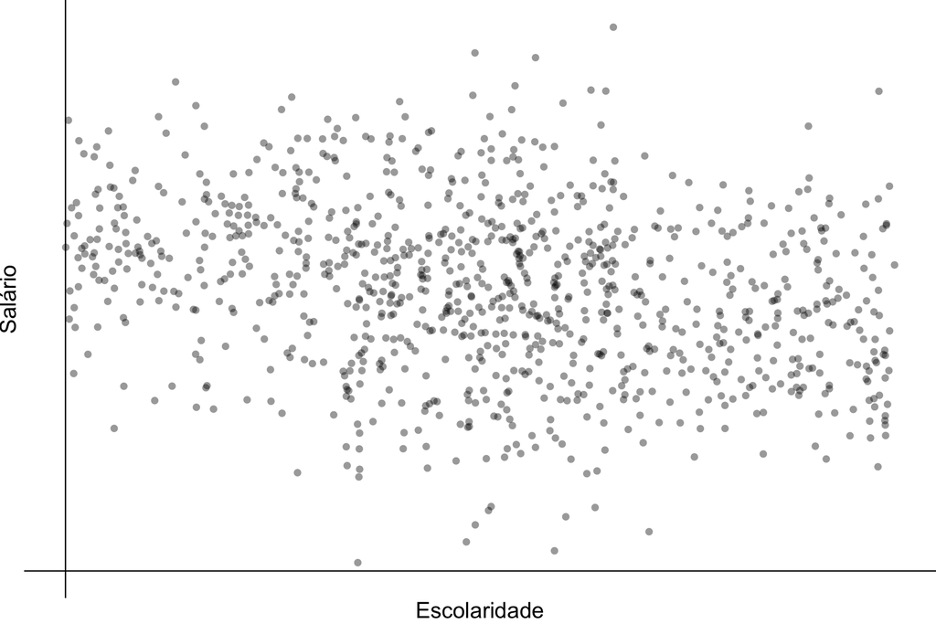

## Viés de Variável Omitida

**Examplo, continuação** $\text{Salário}_i = 20 + 0.5 \times \text{Escolaridade}_i + 10 \times \text{Homem}_i + u_i$

Estimativa viesada da regressão: $\widehat{\text{Salário}}_i = 31.3 -0.9 \times \text{Escolaridade}_i$

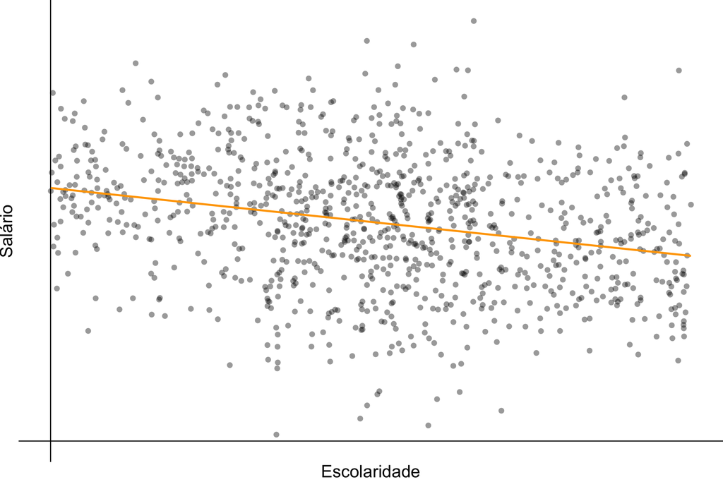

## Viés de Variável Omitida

**Examplo, continuação** $\text{Salário}_i = 20 + 0.5 \times \text{Escolaridade}_i + 10 \times \text{Homem}_i + u_i$

Lembrando a variável omitida: Gênero (**Mulher** e **Homem**)

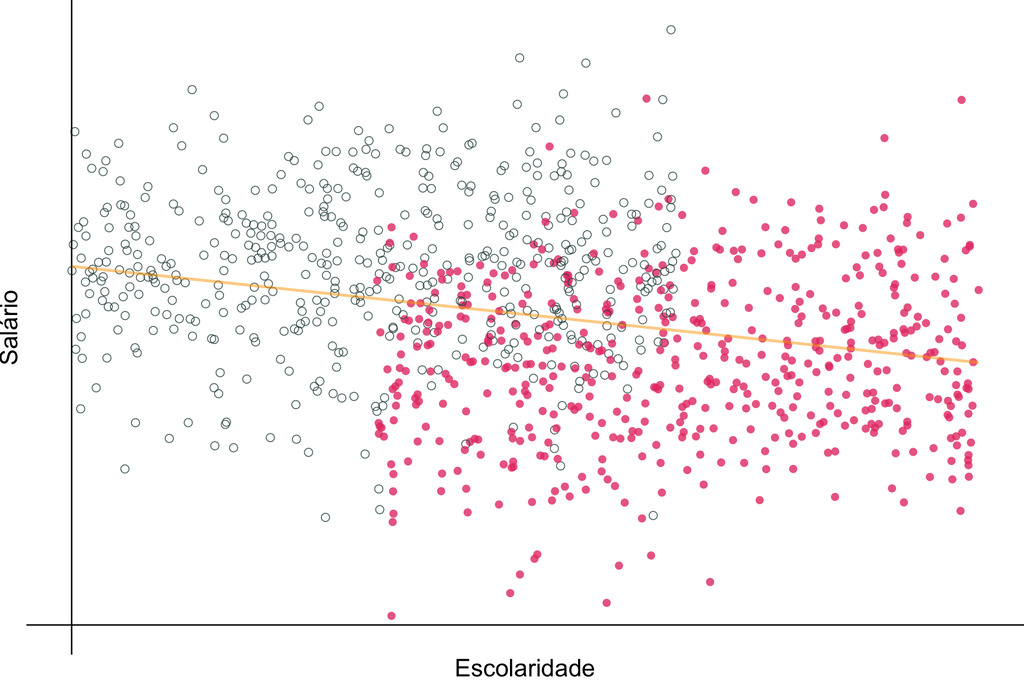

## Viés de Variável Omitida

**Examplo, continuação** $\text{Salário}_i = 20 + 0.5 \times \text{Escolaridade}_i + 10 \times \text{Homem}_i + u_i$

Estimativa não viesada da regressão: $\widehat{\text{Salário}}_i = 20.9 + 0.4 \times \text{Escolaridade}_i + 9.1 \times \text{Homem}_i$

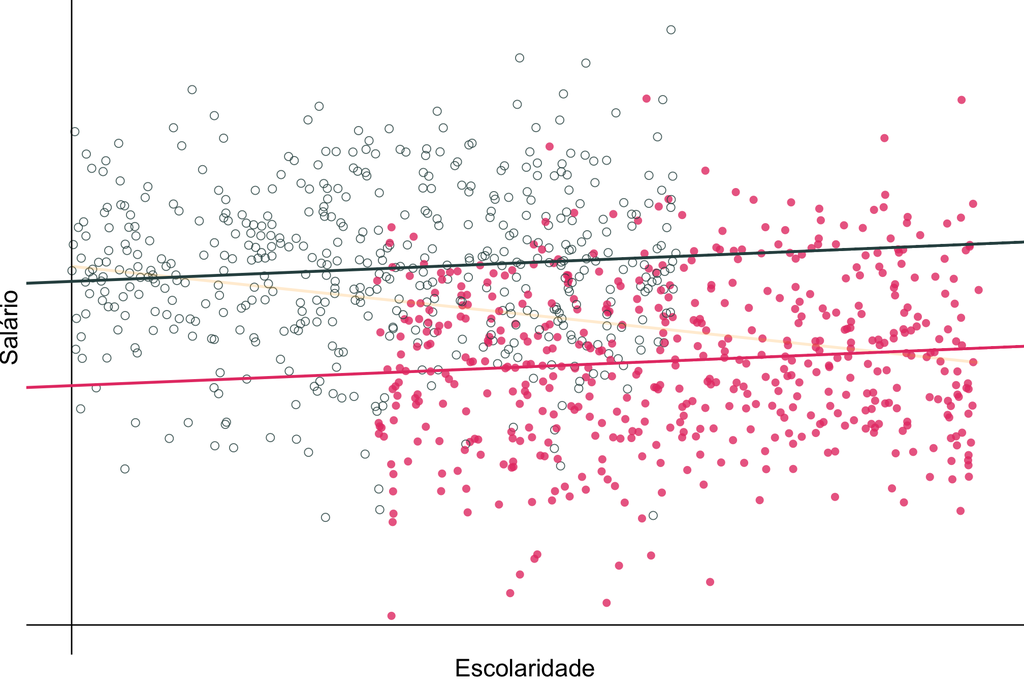

## Viés de Variável Omitida

**Soluções**

- Não omita variáveis.
- **Variáveis instrumentais** e **Mínimos Quadrados em Dois Estágios**.

**Aviso:** Existem situações em que nenhuma dessas soluções é possível.

- Proceda com cautela (às vezes, é possível determinar o sinal do viés).
- Talvez seja melhor parar.

## Teste RESET

**RESET = Regression Specification Error Test**

- O teste RESET testa a endogeneidade devida ao viés de variáveis omitidas e a um tipo de forma funcional incorreta.

**Procedimento:**

Suponha que tenhamos especificado e estimado o modelo:

$$\begin{align*}
y_i &= \beta_1 + \beta_2 x_{i2} + \beta_3 x_{i3} + \epsilon_i \\
\hat{y}_i &= \hat{\beta}_1 + \hat{\beta}_2 x_{i2} + \hat{\beta}_3 x_{i3}
\end{align*}$$

Considere o seguinte modelo artificial:

$$y_i = \beta_1 + \beta_2 x_{i2} + \beta_3 x_{i3} + \gamma_1 \hat{y}_i^2 + \gamma_2 \hat{y}_i^3 + \epsilon_i$$

- Testamos $H_0$: $\gamma_1 = \gamma_2 = 0$ contra $H_A$: $\gamma_1 \neq 0$ ou $\gamma_2 \neq 0$.
- Note que $\hat{y}_i^2$ e $\hat{y}_i^3$ são funções polinomiais de $x_{i2}$ e $x_{i3}$,
- Assim, se o modelo original não possui a forma funciconal correta, a aproximação polinomial que inclui $\hat{y}_i^2$ e $\hat{y}_i^3$ pode melhorar significativamente o ajusde do modelo, e esse fato será detecatado por valores não nulos de $\gamma_1$ e $\gamma_2$.
- Além disso, se tivermos omitido variáveis, e essas variáveis forem correlacionadas com $x_{i2}$ e $x_{i3}$, então, alguns dos seus efeitos podem ser detectados pela inclusão dos termos $\hat{y}_i^2$ e $\hat{y}_i^3$.
- **Ideia geral do teste**: se podemos melhorar significativamente o modelo pela inclusão artificial de potências das predições do modelo, então há evidências de que o modelo original é inadequado, seja devido a **não linearidade** ou a **omissão de variáveis**.

**Regra de Decisão:**

- Valores-p maiores que 0.05 (5%) implicam que a $H_0$ de que o modelo linear é uma especificação adequada, ou seja, a $H_0$ **não** deve ser rejeitada.
- Valores-p menores que 0.05 (5%) implicam que a $H_0$ de que o modelo linear é uma especificação inadequada, ou seja, a $H_0$ **deve** ser rejeitada.

## Teste RESET em R

```r
# pacote necessario
library(lmtest)

# adiciona potências dos valores ajustados (y^2 e y^3)
# verificar se há alguma não linearidade que não foi
# capturada pelo modelo original.
resettest(modelo, power = 2:3, type = "fitted")

# adiciona potências das variáveis explicativas originais ao modelo
# (x_1)^2, (x_1)^3, (x_2)^2, (x_2)^3,...
# verifica possibilidade de variáveis omitidas
resettest(modelo, power = 2:3, type = "regressor")
```

## Teste RESET em R

```r
library(lmtest)

# modelos simulados
x <- c(1:30)
y1 <- 1 + x + x^2 + rnorm(30)
y2 <- 1 + x + rnorm(30)
```

```r
resettest(y1 ~ x, power=2, type="regressor")
```

```
#>
#>  RESET test
#>
#> data:  y1 ~ x
#> RESET = 104795, df1 = 1, df2 = 27, p-value <0.0000000000000002
```

```r
resettest(y1 ~ x + I(x^2), power=2, type="regressor")
```

```
#>
#>  RESET test
#>
#> data:  y1 ~ x + I(x^2)
#> RESET = 1.15, df1 = 2, df2 = 25, p-value = 0.33
```

```r
resettest(y2 ~ x, power=2, type="regressor")
```

```
#>
#>  RESET test
#>
#> data:  y2 ~ x
#> RESET = 0.093, df1 = 1, df2 = 27, p-value = 0.76
```

# Simulação: Viés de Variável Omitida e Multicolinearidade

## Regressão curta x longa

**Descrição**

Goldberger (1991) caracterizou o problema da omissão de variáveis explicativas como a escolha entre uma regressão longa e uma regressão curta.

Esta seção considera a **precisão relativa da regressão longa** em dois casos:

1. quando as variáveis explicativas são **independentes** entre si, e
2. quando as variáveis explicativas são correlacionadas, ou seja, quando apresentam **multicolinearidade**.

## Regressão curta

**Descrição**

- Considere um exemplo em que o verdadeiro efeito é dado pela seguinte **regressão longa**:

$$y_i = a + b x_i + c w_i + v_i$$

- A variável dependente $y_i$ é determinada tanto por $x_i$ quanto por $w_i$ (e por $v_i$).
- No exemplo que estamos analisando, pense em $y_i$ como representando o **salário** do indivíduo $i$.
- O salário é determinada pelos anos de **escolaridade** ($x_i$) e pela **experiência profissional** ($w_i$).
- Ela também é influenciada por **características não observadas** do indivíduo ($v_i$), que podem incluir, por exemplo, características do local onde ele vive, como a taxa de desemprego vigente.
- Nosso interesse está em estimar $b$, isto é, em estimar o **retorno da escolaridade**.
- Se fizemos isso estimando a seguinte **regressão curta**:

$$y_i = \alpha + \beta x_i + \varepsilon_i$$

- introduzimos uma **nova característica não observada**.
- A nova variável de erro, $\varepsilon_i$, combina tanto os efeitos das características não observadas da regressão longa ($v_i$) quanto o efeito potencialmente observável de $w_i$.
- Sabemos que a **experiência afeta a renda**, isso importa?
- Importa deixarmos de fora variáveis explicativas importantes?

**Resposta:** Sim. E não. Talvez. Depende.

## Variáveis Explicativas Independentes

**Descrição**

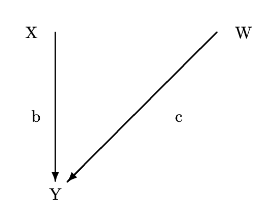

Figura 1: Grafo causal com duas variáveis explicativas independentes.

A Figura 1 apresenta o caso de **independência**.

Existem duas variáveis que determinam o valor de $Y$: $X$ e $W$.

$Y$ representa o salário, $X$ corresponde à **escolaridade**, enquanto $W$ representa a **experiência**.

No entanto, os dois efeitos são **independentes entre si**.

Na figura, essa independência é representada pelo fato de não haver uma linha ligando $X$ a $W$, exceto por meio de $Y.

## Variáveis Explicativas Independentes

**Simulação 1**

- A primeira simulação assume que $x$ e $w$ afetam $y$ de forma **independente**.
- Isto é, embora $x$ e $w$ ambos influenciem $y$, **eles não afetam um ao outro**, nem existe um **fator comum** que os afete simultaneamente.
- Nas simulações, esse fator comum é controlado pelo parâmetro de ponderação $\alpha$.
- Neste caso específico, o peso atribuído ao fator comum que poderia afetar simultaneamente $x$ e $w$ é **zero**, isto é, $\alpha = 0$.

## Simulação 1 - Independência

```r
# Define a semente para reprodutibilidade dos resultados
set.seed(123456789)

# Define o tamanho da amostra
N <- 1000

# define os verdadeiros parâmetros populacionais
a <- 2
b <- 3
c <- 4

# simula um vetor de erro normal padrão para possível correlação entre X e W
u_x <- rnorm(N)

# define o parâmetro de correlação entre X e W
# alpha = 0 -> independência
alpha <- 0

# simula a variável explicativa X de forma aleatória (Uniforme)
x <- x1 <- (1 - alpha) * runif(N) + alpha * u_x

# simula a variável explicativa W de forma aleatória e independente de X
w <- w1 <- (1 - alpha) * runif(N) + alpha * u_x

# Comentário: se alpha = 1, X e W seriam idênticas
# (caso de multicolinearidade perfeita)

# simula o termo de erro aleatório (não observado)
u <- rnorm(N)

# simula a variável dependente Y segundo o modelo populacional verdadeiro
y <- a + b * x + c * w + u

# Estima a regressão curta (Y em função apenas de X)
lm1 <- lm(y ~ x)

# Estima a regressão longa (Y em função de X e W)
lm2 <- lm(y ~ x + w)
```

## Resultados para X e W independentes

|  | *Dependent variable:* |  |
| --- | --- | --- |
|  | y |  |
|  | (1) | (2) |
| x | 3.14*** | 2.81*** |
|  | (0.17) | (0.11) |
| w |  | 4.05*** |
|  |  | (0.11) |
| Constant | 3.98*** | 2.15*** |
|  | (0.10) | (0.08) |
| Observations | 1,000 | 1,000 |
| R<sup>2</sup> | 0.26 | 0.68 |
| *Note:* | *p<0.1; **p<0.05;*** p<0.01 |  |

## Efeito da Omissão de Variável

**Dedução: Caso de Independência entre $X$ e $W$**

Suponha o modelo populacional completo:

$$y_i = a + b x_i + c w_i + v_i$$

Tomando a esperança condicional em $x_i$:

$$\begin{align*}
E(y_i \mid x_i) &= E(a + b x_i + c w_i + v_i \mid x_i) \\
&= a + b x_i + c,E(w_i \mid x_i) + E(v_i \mid x_i)
\end{align*}$$

Assumindo:

- Independência entre $x_i$ e $w_i$: $E(w_i \mid x_i) = E(w_i)$
- Exogeneidade: $E(v_i \mid x_i) = 0$

Temos:

$$E(y_i \mid x_i) = a + b x_i + c,E(w_i)= (a + c,E(w_i)) + b x_i$$

Comparando com a forma da regressão curta:

$$E(y_i \mid x_i) = \alpha + \beta x_i$$

Identificamos:

$$\boxed{\beta = b} \quad \text{e} \quad \boxed{\alpha = a + c,E(w_i)}$$

#### Interpretação

- quando $X$ e $W$ são independentes, omitir $W$ não afeta $\hat b$ em média — mas a reta de regressão é deslocada verticalmente, e a qualidade das estimativas pode ser prejudicada.
- O intercepto absorve o efeito médio de $W$ sobre $Y$:

$$\hat{\alpha} \approx a + c\,\bar{w}.$$

- Assim, a regressão curta **mantém a inclinação correta**, mas **desloca a reta de regressão verticalmente**.
- Ou seja, o intercepto passa a refletir o **efeito médio da variável omitida**, como a **experiência média dos indivíduos** no caso da renda.

## Variáveis Explicativas Dependentes

**Descrição**

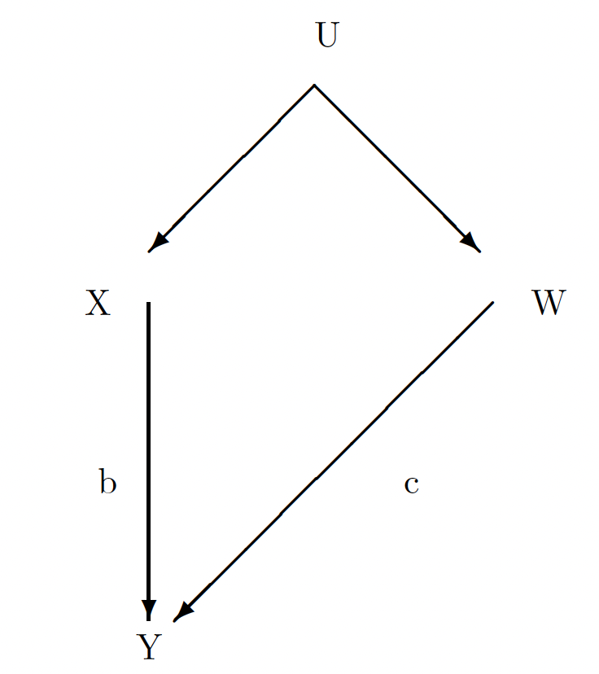

Figura 2: Grafo causal com duas variáveis explicativas dependentes.

$$\hat{b}_{\text{curta}} \approx b + c.$$

## Variáveis Explicativas Dependentes

**Simulação 2**

- A segunda simulação permite a existência de **dependência** entre $x$ e $w$.
- Na simulação, essa dependência é representada por um valor positivo do peso que cada característica atribui ao **fator comum** $u_x$.
- A Tabela mostra que, nesse caso, faz **grande diferença** estimar uma regressão curta ou uma regressão longa.
- A regressão curta produz uma estimativa viesada, pois ela incorpora o efeito de $w$ sobre $y$.
- Quando esse efeito é devidamente incluído na regressão longa, as estimativas tornam-se muito próximas dos valores verdadeiros dos parâmetros.

## Simulação 2 - Dependência

```r
alpha <- 0.5
x <- x2 <- (1 - alpha)*runif(N) + alpha*u_x
w <- w2 <- (1 - alpha)*runif(N) + alpha*u_x
y <- a + b*x + c*w + u
lm3 <- lm(y ~ x)
lm4 <- lm(y ~ x + w)
```

## Resultados para X e W Dependentes

|  | *Dependent variable:* |  |
| --- | --- | --- |
|  | y |  |
|  | (1) | (2) |
| x | 6.84*** | 2.86*** |
|  | (0.08) | (0.17) |
| w |  | 4.16*** |
|  |  | (0.16) |
| Constant | 2.14*** | 2.07*** |
|  | (0.05) | (0.04) |
| Observations | 1,000 | 1,000 |
| R<sup>2</sup> | 0.88 | 0.93 |
| *Note:* | *p<0.1; **p<0.05;*** p<0.01 |  |

## Variáveis Explicativas Muito Dependentes

**Simulação 3**

- A terceira simulação sugere que devemos ter **cautela para não confiar excessivamente em regressões longas**.
- Se $x$ e $w$ são **altamente correlacionadas**, então a regressão curta fornece um efeito combinado (ou duplo), enquanto a regressão longa **produz resultados sem sentido** — ou, em termos coloquiais, **“lixo”**.
- Na verdade, o efeito combinado é obtido somando-se os dois coeficientes. O modelo não consegue separar os dois efeitos.

## Simulação 3 - Muita Dependência

```r
alpha <- 0.95
x <- x3 <- (1 - alpha)*runif(N) + alpha*u_x
w <- w3 <- (1 - alpha)*runif(N) + alpha*u_x
y <- a + b*x + c*w + u
lm5 <- lm(y ~ x)
lm6 <- lm(y ~ x + w)
```

## Resultados para X e W Muito Dependentes

|  | *Dependent variable:* |  |
| --- | --- | --- |
|  | y |  |
|  | (1) | (2) |
| x | 7.01*** | 0.67 |
|  | (0.03) | (1.59) |
| w |  | 6.35*** |
|  |  | (1.59) |
| Constant | 2.07*** | 2.08*** |
|  | (0.03) | (0.03) |
| Observations | 1,000 | 1,000 |
| R<sup>2</sup> | 0.98 | 0.98 |
| *Note:* | *p<0.1; **p<0.05;*** p<0.01 |  |

## Regressão curta x longa

**Conclusão**

- Vimos o que ocorre ao estimar uma **regressão curta** quando há **dependência entre as variáveis**.
- Quando **não há dependência**, a regressão curta apresenta um bom desempenho.
- Entretanto, quando existe **dependência entre as variáveis**, a regressão curta passa a capturar tanto o efeito de $x$ quanto o efeito de $w$ sobre $y$.
- Executar **regressões longas** não é uma solução mágica.
- Se as duas variáveis forem **fortemente correlacionadas**, a regressão longa não consegue distinguir entre os dois efeitos distintos.
- Trata-se de um problema de multicolinearidade.

## Referências

BROOKS, C. **Introductory Econometrics For Finance**. 4th. ed. [s.l.] Cambridge University Press, 2019.

GOLDBERGER, A. S. **A Course in Econometrics**. Cambridge, MA: Harvard University Press, 1991.

WOOLDRIDGE, J. M. **Introdução à Econometria: Uma Abordagem Moderna**. 1. ed. São Paulo: Thomson, 2006.